# Using fgsea package

`fgsea` is an R-package for fast preranked gene set enrichment analysis (GSEA). This package allows to quickly and accurately calculate arbitrarily low GSEA P-values for a collection of gene sets. P-value estimation is based on an adaptive multi-level split Monte-Carlo scheme. See the [preprint](https://www.biorxiv.org/content/10.1101/060012v2) for algorithmic details.

## Loading necessary libraries

```r
library(fgsea)
library(data.table)
library(ggplot2)
```

## Quick run

Loading example pathways and gene-level statistics and setting random seed:

```r
data(examplePathways)
data(exampleRanks)
set.seed(42)
```

Running fgsea:

```r
fgseaRes <- fgsea(pathways = examplePathways,
                  stats    = exampleRanks,
                  minSize  = 15,
                  maxSize  = 500)
```

The resulting table contains enrichment scores and p-values:

```r
head(fgseaRes[order(pval), ])
```

```
##                                            pathway         pval         padj
## 1:                     5990979_Cell_Cycle,_Mitotic 6.690481e-27 3.920622e-24
## 2:                              5990980_Cell_Cycle 3.312565e-26 9.705816e-24
## 3:                    5991851_Mitotic_Prometaphase 8.470173e-19 1.654507e-16
## 4: 5992217_Resolution_of_Sister_Chromatid_Cohesion 2.176649e-18 3.188791e-16
## 5:                                 5991454_M_Phase 1.873997e-14 2.196325e-12
## 6:         5991599_Separation_of_Sister_Chromatids 8.733223e-14 8.529448e-12
##      log2err        ES      NES size                              leadingEdge
## 1: 1.3422338 0.5594755 2.769070  317 66336,66977,12442,107995,66442,12571,...
## 2: 1.3267161 0.5388497 2.705894  369 66336,66977,12442,107995,66442,19361,...
## 3: 1.1239150 0.7253270 2.972690   82 66336,66977,12442,107995,66442,52276,...
## 4: 1.1053366 0.7347987 2.957518   74 66336,66977,12442,107995,66442,52276,...
## 5: 0.9759947 0.5576247 2.554076  173 66336,66977,12442,107995,66442,52276,...
## 6: 0.9545416 0.6164600 2.670030  116 66336,66977,107995,66442,52276,67629,...
```

```r
fgseaRes <- fgsea(pathways = examplePathways,
                  stats    = exampleRanks,
                  eps      = 0.0,
                  minSize  = 15,
                  maxSize  = 500)

head(fgseaRes[order(pval), ])
```

```
##                                            pathway         pval         padj
## 1:                              5990980_Cell_Cycle 2.535645e-26 1.485888e-23
## 2:                     5990979_Cell_Cycle,_Mitotic 9.351994e-26 2.740134e-23
## 3:                    5991851_Mitotic_Prometaphase 3.633805e-19 7.098033e-17
## 4: 5992217_Resolution_of_Sister_Chromatid_Cohesion 2.077985e-17 3.044248e-15
## 5:                                 5991454_M_Phase 2.251818e-14 2.639131e-12
## 6:          5991502_Mitotic_Metaphase_and_Anaphase 3.196758e-14 3.122167e-12
##      log2err        ES      NES size                              leadingEdge
## 1: 1.3344975 0.5388497 2.664606  369 66336,66977,12442,107995,66442,19361,...
## 2: 1.3188888 0.5594755 2.740246  317 66336,66977,12442,107995,66442,12571,...
## 3: 1.1330899 0.7253270 2.926512   82 66336,66977,12442,107995,66442,52276,...
## 4: 1.0768682 0.7347987 2.920436   74 66336,66977,12442,107995,66442,52276,...
## 5: 0.9759947 0.5576247 2.547515  173 66336,66977,12442,107995,66442,52276,...
## 6: 0.9653278 0.6052907 2.639370  123 66336,66977,107995,66442,52276,67629,...
```

One can make an enrichment plot for a pathway:

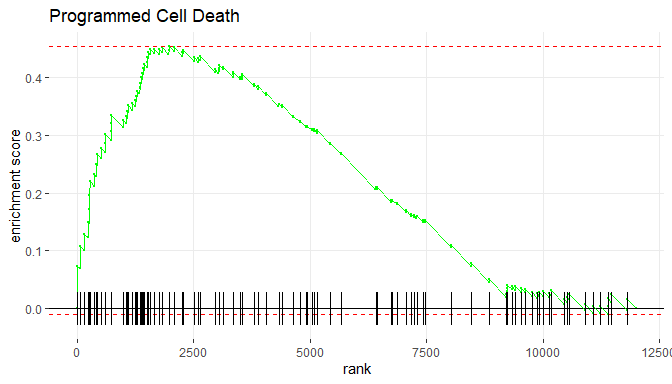

```r
plotEnrichment(examplePathways[["5991130_Programmed_Cell_Death"]],
               exampleRanks) + labs(title="Programmed Cell Death")
```

Or make a table plot for a bunch of selected pathways:

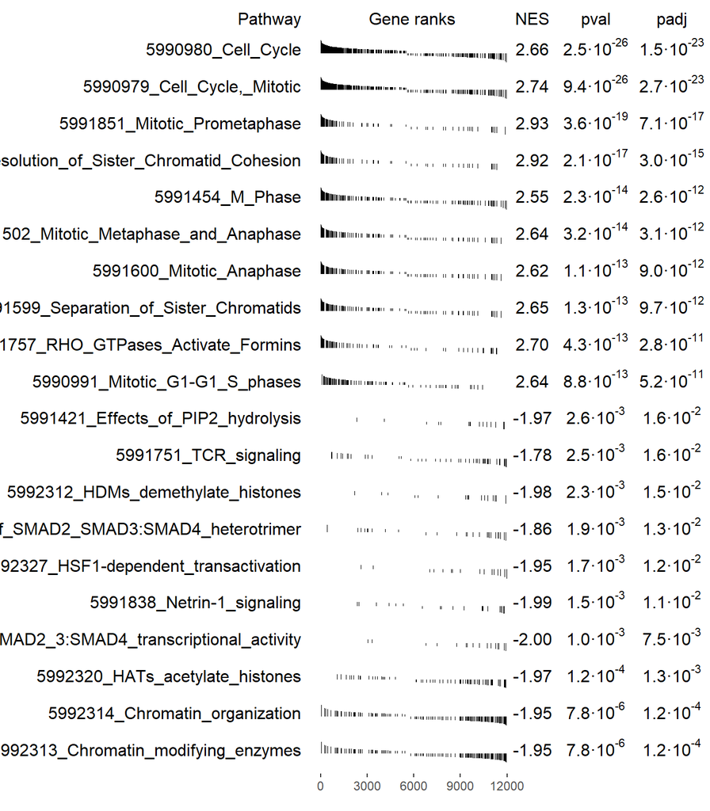

```r
topPathwaysUp <- fgseaRes[ES > 0][head(order(pval), n=10), pathway]
topPathwaysDown <- fgseaRes[ES < 0][head(order(pval), n=10), pathway]
topPathways <- c(topPathwaysUp, rev(topPathwaysDown))
plotGseaTable(examplePathways[topPathways], exampleRanks, fgseaRes,
              gseaParam=0.5)
```

From the plot above one can see that there are very similar pathways in the table (for example `5991502_Mitotic_Metaphase_and_Anaphase` and `5991600_Mitotic_Anaphase`). To select only independent pathways one can use `collapsePathways` function:

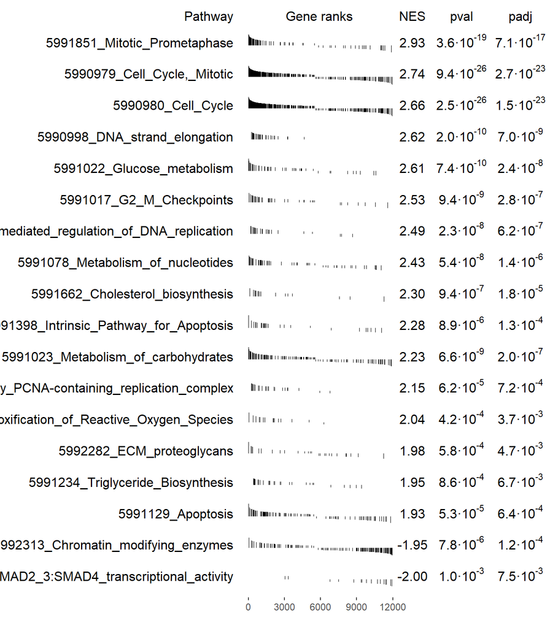

```r
collapsedPathways <- collapsePathways(fgseaRes[order(pval)][padj < 0.01],
                                      examplePathways, exampleRanks)
mainPathways <- fgseaRes[pathway %in% collapsedPathways$mainPathways][
                         order(-NES), pathway]
plotGseaTable(examplePathways[mainPathways], exampleRanks, fgseaRes,
              gseaParam = 0.5)
```

To save the results in a text format `data:table::fwrite` function can be used:

```r
fwrite(fgseaRes, file="fgseaRes.txt", sep="\t", sep2=c("", " ", ""))
```

To make leading edge more human-readable it can be converted using `mapIdsList` (similar to `AnnotationDbi::mapIds`) function and a corresponding database (here `org.Mm.eg.db` for mouse):

```r
library(org.Mm.eg.db)
fgseaResMain <- fgseaRes[match(mainPathways, pathway)]
fgseaResMain[, leadingEdge := mapIdsList(
                                     x=org.Mm.eg.db,
                                     keys=leadingEdge,
                                     keytype="ENTREZID",
                                     column="SYMBOL")]
fwrite(fgseaResMain, file="fgseaResMain.txt", sep="\t", sep2=c("", " ", ""))
```

## Performance considerations

Also, `fgsea` is parallelized using `BiocParallel` package. By default the first registered backend returned by `bpparam()` is used. To tweak the parallelization one can either specify `BPPARAM` parameter used for `bplapply` of set `nproc` parameter, which is a shorthand for setting `BPPARAM=MulticoreParam(workers = nproc)`.

## Using Reactome pathways

For convenience there is `reactomePathways` function that obtains pathways from Reactome for given set of genes. Package `reactome.db` is required to be installed.

```r
pathways <- reactomePathways(names(exampleRanks))
fgseaRes <- fgsea(pathways, exampleRanks, maxSize=500)
head(fgseaRes)
```

```
##                                                            pathway        pval
## 1:                      5-Phosphoribose 1-diphosphate biosynthesis 0.836852207
## 2: A tetrasaccharide linker sequence is required for GAG synthesis 0.538888889
## 3:                           ABC transporters in lipid homeostasis 0.212389381
## 4:                          ABC-family proteins mediated transport 0.441082803
## 5:                                    ABO blood group biosynthesis 0.977130977
## 6:                       ADP signalling through P2Y purinoceptor 1 0.006665003
##          padj    log2err         ES        NES size
## 1: 0.94172298 0.05195125 -0.5732978 -0.7611322    1
## 2: 0.80089479 0.07130530  0.3755168  0.9477427   10
## 3: 0.55501753 0.14040624 -0.4385385 -1.2568451   12
## 4: 0.75264848 0.07380527  0.2614189  1.0132771   66
## 5: 0.98673503 0.04850598  0.5120427  0.6803769    1
## 6: 0.06477916 0.40701792  0.6228710  1.7905520   16
##                                 leadingEdge
## 1:                                    19139
## 2: 14733,20971,20970,12032,29873,218271,...
## 3: 19299,27403,11307,11806,217265,27409,...
## 4: 17463,26440,26444,19179,228769,56325,...
## 5:                                    14344
## 6:  14696,14702,14700,14682,14676,66066,...
```

## Starting from files

One can also start from `.rnk` and `.gmt` files as in original GSEA:

```r
rnk.file <- system.file("extdata", "naive.vs.th1.rnk", package="fgsea")
gmt.file <- system.file("extdata", "mouse.reactome.gmt", package="fgsea")
```

Loading ranks:

```r
ranks <- read.table(rnk.file,
                    header=TRUE, colClasses = c("character", "numeric"))
ranks <- setNames(ranks$t, ranks$ID)
str(ranks)
```

```
##  Named num [1:12000] -63.3 -49.7 -43.6 -41.5 -33.3 ...
##  - attr(*, "names")= chr [1:12000] "170942" "109711" "18124" "12775" ...
```

Loading pathways:

```r
pathways <- gmtPathways(gmt.file)
str(head(pathways))
```

```
## List of 6
##  $ 1221633_Meiotic_Synapsis                                                : chr [1:64] "12189" "13006" "15077" "15078" ...
##  $ 1368092_Rora_activates_gene_expression                                  : chr [1:9] "11865" "12753" "12894" "18143" ...
##  $ 1368110_Bmal1:Clock,Npas2_activates_circadian_gene_expression           : chr [1:16] "11865" "11998" "12753" "12952" ...
##  $ 1445146_Translocation_of_Glut4_to_the_Plasma_Membrane                   : chr [1:55] "11461" "11465" "11651" "11652" ...
##  $ 186574_Endocrine-committed_Ngn3+_progenitor_cells                       : chr [1:4] "18012" "18088" "18506" "53626"
##  $ 186589_Late_stage_branching_morphogenesis_pancreatic_bud_precursor_cells: chr [1:4] "11925" "15205" "21410" "246086"
```

And running fgsea:

```r
fgseaRes <- fgsea(pathways, ranks, minSize=15, maxSize=500)
head(fgseaRes)
```

```
##                                                                                    pathway
## 1:                                                                1221633_Meiotic_Synapsis
## 2:                                   1445146_Translocation_of_Glut4_to_the_Plasma_Membrane
## 3: 442533_Transcriptional_Regulation_of_Adipocyte_Differentiation_in_3T3-L1_Pre-adipocytes
## 4:                                                                  508751_Circadian_Clock
## 5:                                               5334727_Mus_musculus_biological_processes
## 6:                                        573389_NoRC_negatively_regulates_rRNA_expression
##         pval      padj    log2err         ES        NES size
## 1: 0.5483333 0.7251271 0.06523531  0.2885754  0.9412385   27
## 2: 0.6857610 0.8336764 0.05378728  0.2387284  0.8387184   39
## 3: 0.1362468 0.3150882 0.19381330 -0.3640706 -1.3431389   31
## 4: 0.7779661 0.8806609 0.04959020  0.2516324  0.7382131   17
## 5: 0.3884892 0.5913108 0.07511816  0.2469065  1.0473836  106
## 6: 0.4101695 0.6090340 0.08085892  0.3607407  1.0583037   17
##                                 leadingEdge
## 1:                  15270,12189,71846,19357
## 2:  17918,19341,20336,22628,22627,20619,...
## 3: 76199,19014,26896,229003,17977,17978,...
## 4:                        20893,59027,19883
## 5:  60406,19361,15270,20893,12189,68240,...
## 6:                 60406,20018,245688,20017
```